# CÃ³digo TFM

## Análisis de conjuntos de genes (GSA)

El siguiente análisis que se va a realizar es sobre conjuntos de genes para determinar cuáles tienen asociación positiva con la variable y determinar si el resultado es similar al obtenido en el análisis anterior.

Primero, se dividen los datos de los genes en conjuntos mediante los grupos establecidos en Gene Ontology utilizando la anotación en la que se encuentran los genes.

```r
library(annotate)
annotation(GSE5460_mas5)
```

```
## [1] "hgu133plus2"
```

```r
library(hgu133plus2.db)
library(GSEABase)
gse5460.gsc = GeneSetCollection(GSE5460_mas5_filt,setType=GOCollection())
names(gse5460.gsc) = unlist(lapply(gse5460.gsc,setName))
gsc = gse5460.gsc
```

```r
gruposGrandes = gsc[which(sapply(geneIds(gsc),length) > 50)]
gse = GSE5460_mas5_filt
```

Al igual que con el análisis anterior, se realiza el procedimiento con las variables “node_status”, “HER2” y “ER”.

```r
node.num = as.numeric(pData(gse)[,"node_status"])
pacman::p_load(GSA)
gse5460.gsa = GSA(exprs(gse),node.num, genenames=featureNames(gse),genesets=geneIds(gsc),resp.type="Two class unpaired", nperms=1000)
```

[output not shown]

[output cut: 45 more lines]

[output not shown]

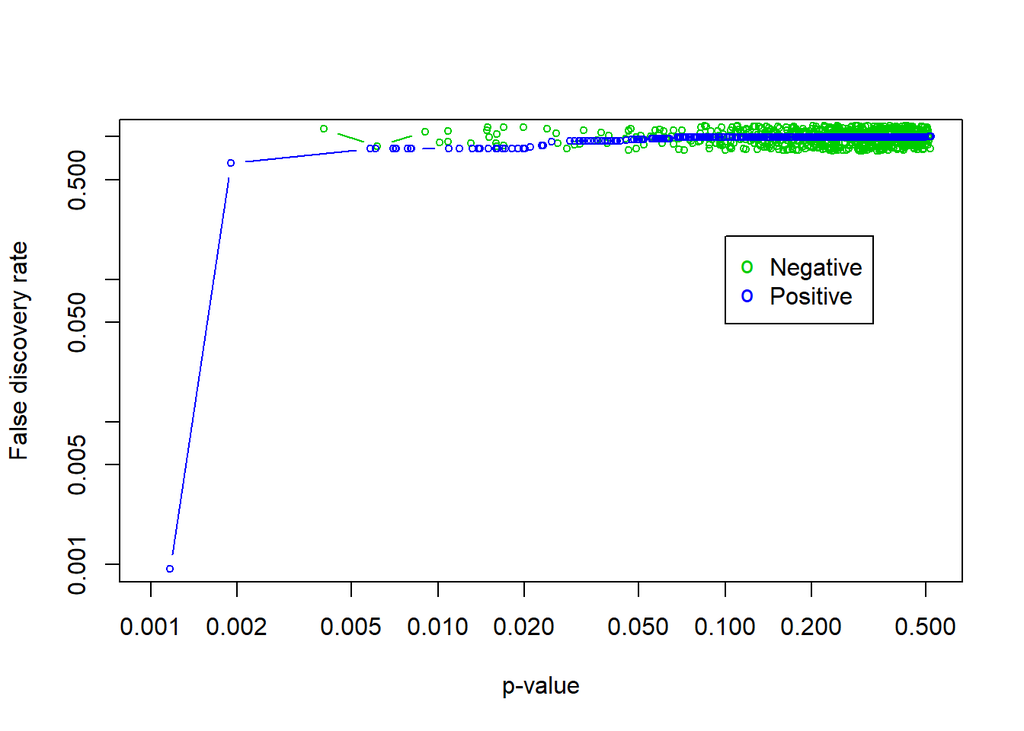

```r
GSA.plot(gse5460.gsa)
```

Genes con asociación negativa:

```r
(ind.lo = which(gse5460.gsa$pvalues.lo <.05))
```

```
##  [1]   954  1196  1343  1463  1498  1503  1746  2674  2775  2813  3794  4040
## [13]  4085  4148  4211  4241  4327  4615  5053  5653  5740  6478  6635  6718
## [25]  7371  7578  8718  9368 10052 10056 10211 11256 11445 11774 12371 13077
```

```r
head(names(gsc[ind.lo]))
```

```
##   GO:0000002   GO:0000012   GO:0000018   GO:0000022   GO:0000023   GO:0000027
## "GO:0006486" "GO:0006936" "GO:0007219" "GO:0007623" "GO:0008219" "GO:0008284"
```

Genes con asociación positiva:

```r
(ind.hi = which(gse5460.gsa$pvalues.hi <.05))
```

```
##  [1]   843   867  1064  1126  1157  1165  1167  1174  1185  1224  1505  1998
## [13]  2056  2228  2636  2676  2803  2975  3085  3213  3234  3361  3456  3742
## [25]  3853  4046  4078  4173  4248  4367  5067  5286  5318  5508  6351  6975
## [37]  7178  7275  7610  9286  9290  9428  9543  9667  9692  9759  9783  9984
## [49] 10018 10306 10339 10651 11203 11354 11440 11953 11997 12008 12070 12112
## [61] 12114 12440 12467 12605 12815 12817
```

```r
head(names(gsc[ind.hi]))
```

```
##   GO:0000002   GO:0000012   GO:0000018   GO:0000022   GO:0000023   GO:0000027
## "GO:0006298" "GO:0006351" "GO:0006661" "GO:0006805" "GO:0006874" "GO:0006886"
```

Los identificadores de los grupos de genes se guardan en archivos separados para su posterior análisis:

```r
neg=names(gsc[ind.lo])
pos=names(gsc[ind.hi])
write.csv(neg, file = "neg_node_status.csv")
write.csv(pos, file = "pos_node_status.csv")
```

Se repite el proceso para la variable “HER2”:

```r
node.num = as.numeric(pData(gse)[,"HER2"])
pacman::p_load(GSA)
gse5460.gsa = GSA(exprs(gse),node.num, genenames=featureNames(gse),genesets=geneIds(gsc),resp.type="Two class unpaired", nperms=1000)
```

[output not shown]

[output cut: 45 more lines]

[output not shown]

Genes con asociación negativa:

```r
(ind.lo = which(gse5460.gsa$pvalues.lo <.05))
```

```
##  [1]   246   279  1026  1263  1285  1343  1347  1366  1399  1408  1424  1426
## [13]  1487  1498  1525  1539  2187  2642  2699  2847  2955  2981  3449  3997
## [25]  4337  4341  4859  5237  5509  5784  5802  5864  5911  6635  7208  9375
## [37]  9376  9688  9692  9908  9962 10056 10211 10498 10499 10502 10534 10634
## [49] 10635 10666 11327 11876 11997 12794
```

```r
head(names(gsc[ind.lo]))
```

```
##   GO:0000002   GO:0000012   GO:0000018   GO:0000022   GO:0000023   GO:0000027
## "GO:0001843" "GO:0001942" "GO:0006605" "GO:0007050" "GO:0007098" "GO:0007219"
```

Genes con asociación positiva:

```r
(ind.hi = which(gse5460.gsa$pvalues.hi <.05))
```

```
##  [1]    38   955  1175  1305  1306  1491  1602  1680  1756  1757  1998  2002
## [13]  2184  2281  2598  2698  2722  2911  2975  3060  3105  3570  3944  3957
## [25]  4138  4169  4300  4333  4370  4665  4721  4729  5326  5378  6165  6665
## [37]  6975  7178  9303  9304  9312  9355  9421  9783  9878  9880  9933 10356
## [49] 10603 11128 11139 11200 11350 11357 11935 11954 12764
```

```r
head(names(gsc[ind.hi]))
```

```
##   GO:0000002   GO:0000012   GO:0000018   GO:0000022   GO:0000023   GO:0000027
## "GO:0000188" "GO:0006487" "GO:0006898" "GO:0007162" "GO:0007163" "GO:0008203"
```

Los identificadores de los grupos de genes se guardan en archivos separados para su posterior análisis:

```r
neg=names(gsc[ind.lo])
pos=names(gsc[ind.hi])
write.csv(neg, file = "neg_HER2.csv")
write.csv(pos, file = "pos_HER2.csv")
```

Se vuelve a repetir el proceso para la variable “ER”:

```r
node.num = as.numeric(pData(gse)[,"ER"])
pacman::p_load(GSA)
gse5460.gsa = GSA(exprs(gse),node.num, genenames=featureNames(gse),genesets=geneIds(gsc),resp.type="Two class unpaired", nperms=1000)
```

[output not shown]

[output cut: 45 more lines]

[output not shown]

Genes con asociación negativa:

```r
(ind.lo = which(gse5460.gsa$pvalues.lo <.05))
```

```
##   [1]    16    20    45    46    65    81    99   364   365   440   745   747
##  [13]   751   815   845   846   851   908   914   937   975  1265  1267  1276
##  [25]  1306  1376  1752  1753  1961  1962  2134  2226  2505  2833  2851  2852
##  [37]  3101  3311  3410  3734  3858  3932  3943  3944  4183  4267  4351  4537
##  [49]  4710  5030  5493  5521  5529  5745  5803  6261  6297  6393  6469  6476
##  [61]  6478  7152  7207  7323  7649  7780  7783  7791  8663  9089  9102  9104
##  [73]  9105  9106  9112  9218  9248  9258  9281  9316  9324  9343  9562  9723
##  [85]  9855  9890 10087 10411 10491 10517 10536 10637 10643 10646 10835 11121
##  [97] 11256 11361 11393 11434 11795 12422 12787 12799 12895 12969
```

```r
head(names(gsc[ind.lo]))
```

```
##   GO:0000002   GO:0000012   GO:0000018   GO:0000022   GO:0000023   GO:0000027
## "GO:0000070" "GO:0000082" "GO:0000278" "GO:0000281" "GO:0000387" "GO:0000462"
```

Genes con asociación positiva:

```r
(ind.hi = which(gse5460.gsa$pvalues.hi <.05))
```

```
##  [1]    64   183   198   203   229   871   873  1174  1329  1362  1399  1404
## [13]  1424  1449  1510  1527  1652  1656  1661  1668  1669  1675  1690  1783
## [25]  1795  2141  2636  2639  2712  2714  2738  2743  2843  3030  3246  3253
## [37]  3413  3577  4167  4342  4396  4638  4681  4730  4793  5025  5039  5297
## [49]  5421  5432  5676  5864  6008  6658  9061  9116  9306  9375  9377  9485
## [61]  9554  9557  9585  9688  9692  9908  9985 10534 10535 10538 10566 10567
## [73] 10582 10583 10647 10666 11137 11208 11214 11238 11347 11354 11875 11935
## [85] 12504 12530 12576 12987
```

```r
head(names(gsc[ind.hi]))
```

```
##   GO:0000002   GO:0000012   GO:0000018   GO:0000022   GO:0000023   GO:0000027
## "GO:0000381" "GO:0001701" "GO:0001755" "GO:0001764" "GO:0001822" "GO:0006355"
```

Los identificadores de los grupos de genes se guardan en archivos separados para su posterior análisis:

```r
neg=names(gsc[ind.lo])
pos=names(gsc[ind.hi])
write.csv(neg, file = "neg_ER.csv")
write.csv(pos, file = "pos_ER.csv")
```